# IE48B - HW1

H.Pınar Yıldırım

05 11 2021

Data of each dimension is read:

```r
setwd("C:/Users/Pınar YILDIRIM/Desktop/ie48b/hw1")
getwd()
```

```
## [1] "C:/Users/Pınar YILDIRIM/Desktop/ie48b/hw1"
```

```r
rm(list=ls())
library(scatterplot3d)
library(data.table)
library(ggplot2)

x = read.table("C:/Users/Pınar YILDIRIM/Desktop/ie48b/hw1/uWaveGestureLibrary_X_TRAIN")
y = read.table("C:/Users/Pınar YILDIRIM/Desktop/ie48b/hw1/uWaveGestureLibrary_Y_TRAIN")
z = read.table("C:/Users/Pınar YILDIRIM/Desktop/ie48b/hw1/uWaveGestureLibrary_Z_TRAIN")
```

X values are seperated according to the classes:

```r
print("Class 1 x")
```

```
## [1] "Class 1 x"
```

```r
class1_x = x[x$V1==1,]
class1_x = class1_x[,-1]


print("Class 2 x")
```

```
## [1] "Class 2 x"
```

```r
class2_x = x[x$V1==2,]
class2_x = class2_x[,-1]

print("Class 3 x")
```

```
## [1] "Class 3 x"
```

```r
class3_x = x[x$V1==3,]
class3_x = class3_x[,-1]


print("Class 4 x")
```

```
## [1] "Class 4 x"
```

```r
class4_x = x[x$V1==4,]
class4_x = class4_x[,-1]



print("Class 5 x")
```

```
## [1] "Class 5 x"
```

```r
class5_x = x[x$V1==5,]
class5_x = class5_x[,-1]



print("Class 6 x")
```

```
## [1] "Class 6 x"
```

```r
class6_x = x[x$V1==6,]
class6_x = class6_x[,-1]


print("Class 7 x")
```

```
## [1] "Class 7 x"
```

```r
class7_x = x[x$V1==7,]
class7_x = class7_x[,-1]



print("Class 8 x")
```

```
## [1] "Class 8 x"
```

```r
class8_x = x[x$V1==8,]
class8_x = class8_x[,-1]
```

Y values are seperated according to the classes:

```r
print("Class 1 y")
```

```
## [1] "Class 1 y"
```

```r
class1_y = y[y$V1==1,]
class1_y = class1_y[,-1]


print("Class 2 y")
```

```
## [1] "Class 2 y"
```

```r
class2_y = y[y$V1==2,]
class2_y = class2_y[,-1]

print("Class 3 y")
```

```
## [1] "Class 3 y"
```

```r
class3_y = y[y$V1==3,]
class3_y = class3_y[,-1]


print("Class 4 y")
```

```
## [1] "Class 4 y"
```

```r
class4_y = y[y$V1==4,]
class4_y = class4_y[,-1]



print("Class 5 y")
```

```
## [1] "Class 5 y"
```

```r
class5_y = y[y$V1==5,]
class5_y = class5_y[,-1]



print("Class 6 y")
```

```
## [1] "Class 6 y"
```

```r
class6_y = y[y$V1==6,]
class6_y = class6_y[,-1]


print("Class 7 y")
```

```
## [1] "Class 7 y"
```

```r
class7_y = y[y$V1==7,]
class7_y = class7_y[,-1]



print("Class 8 y")
```

```
## [1] "Class 8 y"
```

```r
class8_y = y[y$V1==8,]
class8_y= class8_y[,-1]
```

Z values are seperated according to the classes:

```r
print("Class 1 z")
```

```
## [1] "Class 1 z"
```

```r
class1_z = z[z$V1==1,]
class1_z = class1_z[,-1]


print("Class 2 z")
```

```
## [1] "Class 2 z"
```

```r
class2_z = z[z$V1==2,]
class2_z = class2_z[,-1]

print("Class 3 z")
```

```
## [1] "Class 3 z"
```

```r
class3_z = z[z$V1==3,]
class3_z = class3_z[,-1]


print("Class 4 z")
```

```
## [1] "Class 4 z"
```

```r
class4_z = z[z$V1==4,]
class4_z = class4_z[,-1]


print("Class 5 z")
```

```
## [1] "Class 5 z"
```

```r
class5_z = z[z$V1==5,]
class5_z = class5_z[,-1]



print("Class 6 z")
```

```
## [1] "Class 6 z"
```

```r
class6_z= z[z$V1==6,]
class6_z = class6_z[,-1]


print("Class 7 z")
```

```
## [1] "Class 7 z"
```

```r
class7_z = z[z$V1==7,]
class7_z = class7_z[,-1]



print("Class 8 z")
```

```
## [1] "Class 8 z"
```

```r
class8_z = z[z$V1==8,]
class8_z= class8_z[,-1]
```

## 1)

Velocities are calculated as the cumulative sum of accelerations and similarly locations at each time are calculated as the cumulative sum of velocities.

# 3D PLOT for CLASS 1

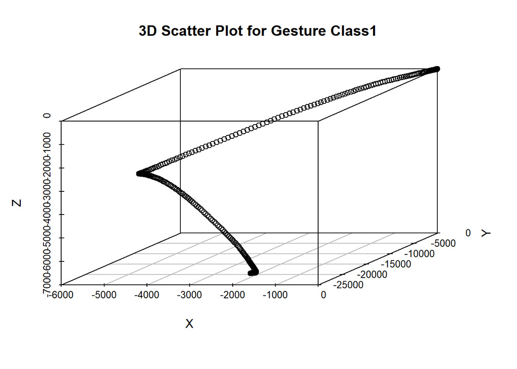

```r
t_class1_x=as.data.frame(t(class1_x[,]))
velocity_class1_x=cumsum(t_class1_x)
loc_class1_x=cumsum(velocity_class1_x)

t_class1_y=as.data.frame(t(class1_y[,]))
velocity_class1_y=cumsum(t_class1_y)
loc_class1_y=cumsum(velocity_class1_y)

t_class1_z=as.data.frame(t(class1_z[,]))
velocity_class1_z=cumsum(t_class1_z)
loc_class1_z=cumsum(velocity_class1_z)

scatterplot3d(  x=loc_class1_x[,1], y=loc_class1_y[,1], z=loc_class1_z[,1], main="3D Scatter Plot for Gesture Class1",
                xlab = "X", ylab= "Y", zlab="Z")
```

# 3D PLOT for CLASS 2

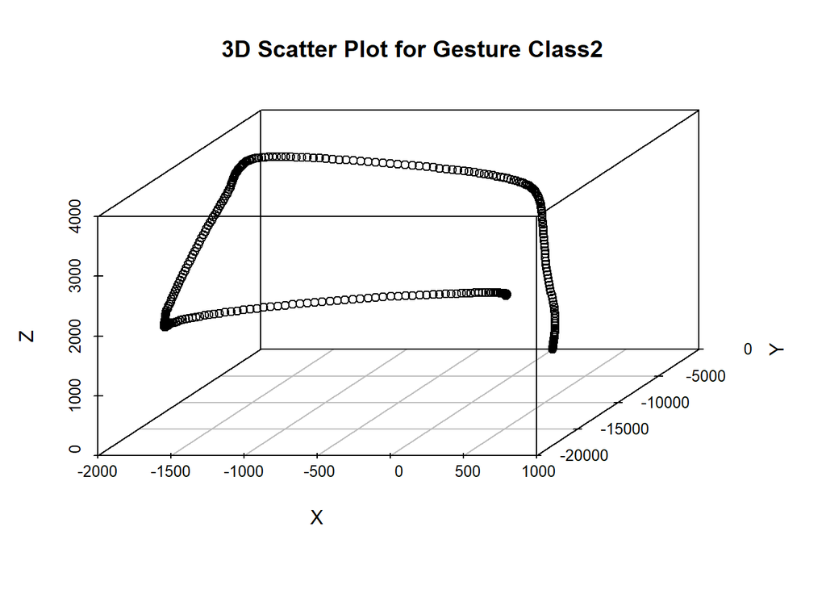

```r
t_class2_x=as.data.frame(t(class2_x[,]))
velocity_class2_x=cumsum(t_class2_x)
loc_class2_x=cumsum(velocity_class2_x)

t_class2_y=as.data.frame(t(class2_y[,]))
velocity_class2_y=cumsum(t_class2_y)
loc_class2_y=cumsum(velocity_class2_y)

t_class2_z=as.data.frame(t(class2_z[,]))
velocity_class2_z=cumsum(t_class2_z)
loc_class2_z=cumsum(velocity_class2_z)

scatterplot3d(x=loc_class2_x[,2], y=loc_class2_y[,2], z=loc_class2_z[,2],main="3D Scatter Plot for Gesture Class2",
              xlab = "X", ylab= "Y", zlab="Z")
```

# 3D PLOT for CLASS 3

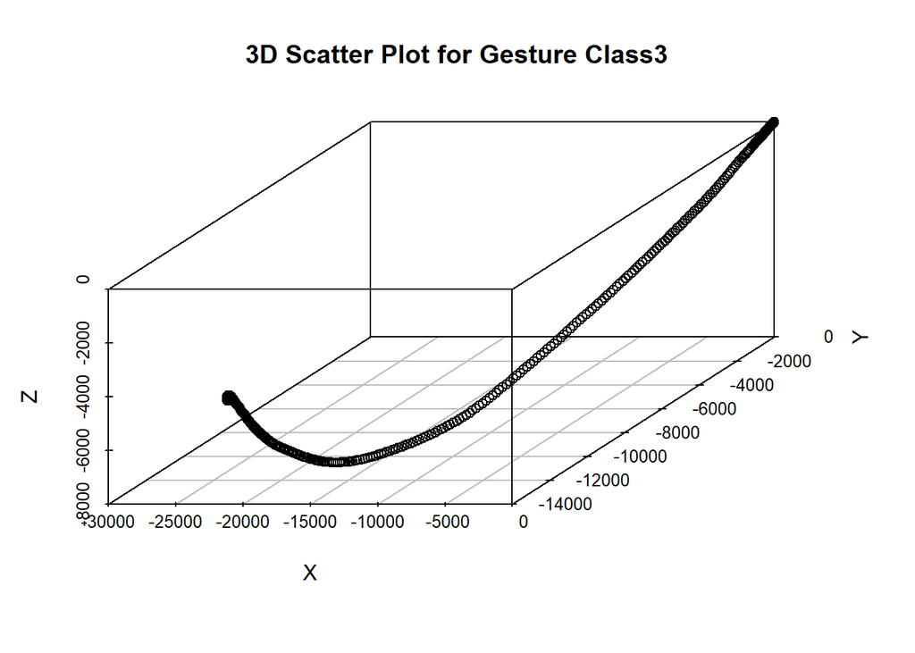

```r
t_class3_x=as.data.frame(t(class3_x[,]))
velocity_class3_x=cumsum(t_class3_x)
loc_class3_x=cumsum(velocity_class3_x)

t_class3_y=as.data.frame(t(class3_y[,]))
velocity_class3_y=cumsum(t_class3_y)
loc_class3_y=cumsum(velocity_class3_y)

t_class3_z=as.data.frame(t(class3_z[,]))
velocity_class3_z=cumsum(t_class3_z)
loc_class3_z=cumsum(velocity_class3_z)

scatterplot3d(x=loc_class3_x[,3], y=loc_class3_y[,3], z=loc_class3_z[,3],main="3D Scatter Plot for Gesture Class3",
              xlab = "X", ylab= "Y", zlab="Z")
```

# 3D PLOT for CLASS 4

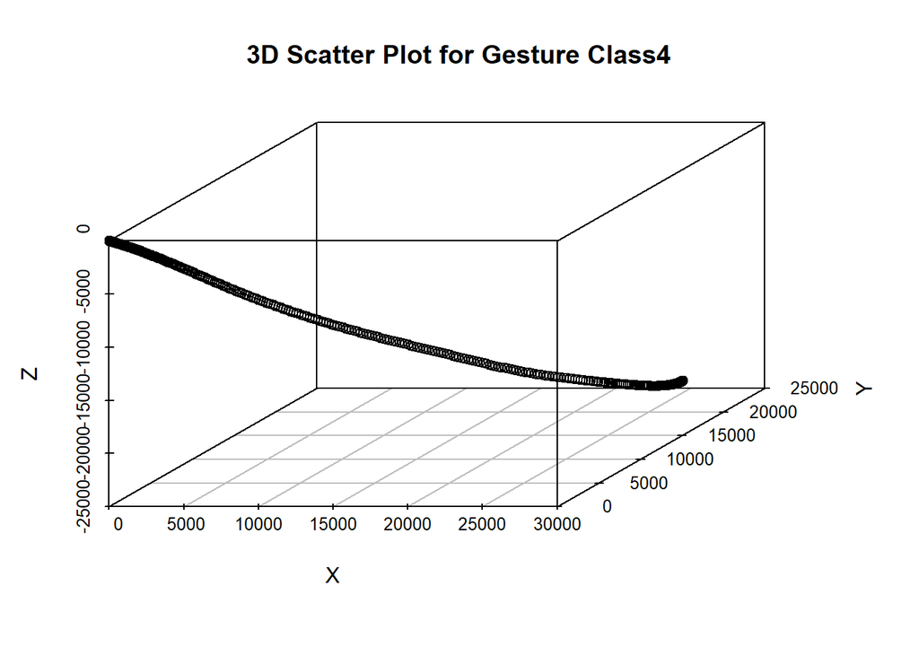

```r
t_class4_x=as.data.frame(t(class4_x[,]))
velocity_class4_x=cumsum(t_class4_x)
loc_class4_x=cumsum(velocity_class4_x)

t_class4_y=as.data.frame(t(class4_y[,]))
velocity_class4_y=cumsum(t_class4_y)
loc_class4_y=cumsum(velocity_class4_y)

t_class4_z=as.data.frame(t(class4_z[,]))
velocity_class4_z=cumsum(t_class4_z)
loc_class4_z=cumsum(velocity_class4_z)

scatterplot3d(x=loc_class4_x[,3], y=loc_class4_y[,3], z=loc_class4_z[,3],main="3D Scatter Plot for Gesture Class4",
              xlab = "X", ylab= "Y", zlab="Z")
```

# 3D PLOT for CLASS 5

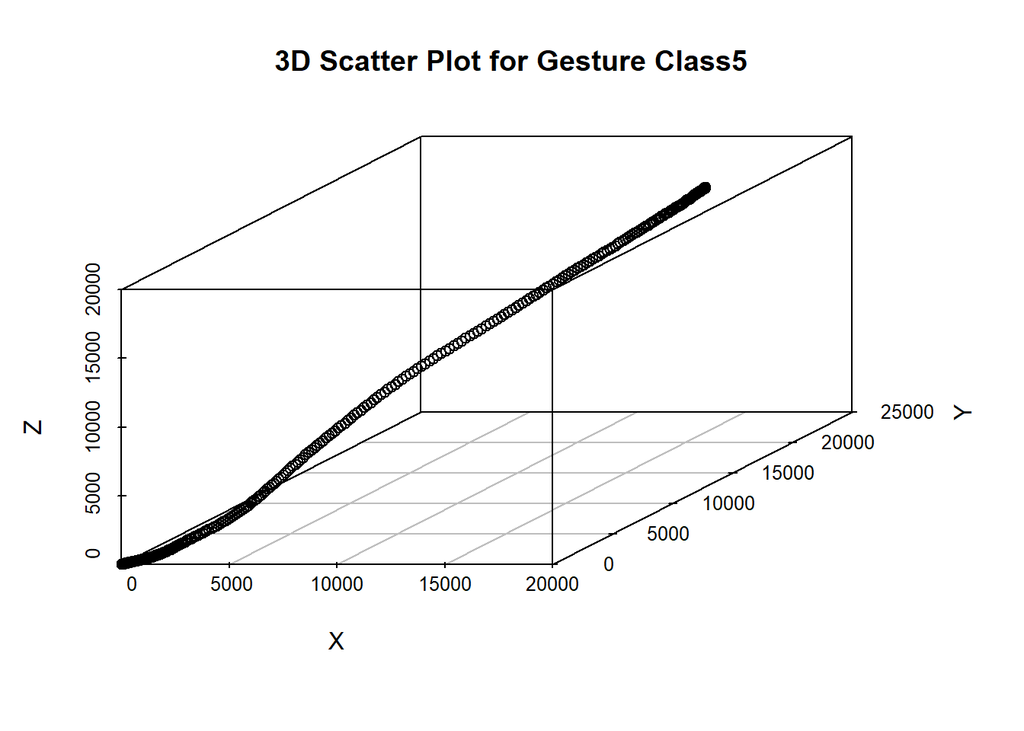

```r
t_class5_x=as.data.frame(t(class5_x[,]))
velocity_class5_x=cumsum(t_class5_x)
loc_class5_x=cumsum(velocity_class5_x)

t_class5_y=as.data.frame(t(class5_y[,]))
velocity_class5_y=cumsum(t_class5_y)
loc_class5_y=cumsum(velocity_class5_y)

t_class5_z=as.data.frame(t(class5_z[,]))
velocity_class5_z=cumsum(t_class5_z)
loc_class5_z=cumsum(velocity_class5_z)

scatterplot3d(x=loc_class5_x[,14], y=loc_class5_y[,14], z=loc_class5_z[,14],main="3D Scatter Plot for Gesture Class5",
              xlab = "X", ylab= "Y", zlab="Z")
```

# 3D PLOT for CLASS 6

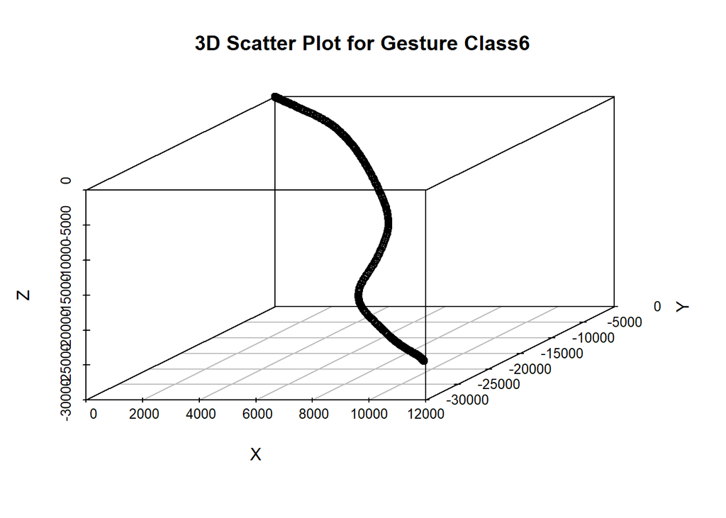

```r
t_class6_x=as.data.frame(t(class6_x[,]))
velocity_class6_x=cumsum(t_class6_x)
loc_class6_x=cumsum(velocity_class6_x)

t_class6_y=as.data.frame(t(class6_y[,]))
velocity_class6_y=cumsum(t_class6_y)
loc_class6_y=cumsum(velocity_class6_y)

t_class6_z=as.data.frame(t(class6_z[,]))
velocity_class6_z=cumsum(t_class6_z)
loc_class6_z=cumsum(velocity_class6_z)

scatterplot3d(x=loc_class6_x[,6], y=loc_class6_y[,6], z=loc_class6_z[,6],main="3D Scatter Plot for Gesture Class6",
              xlab = "X", ylab= "Y", zlab="Z")
```

# 3D PLOT for CLASS 7

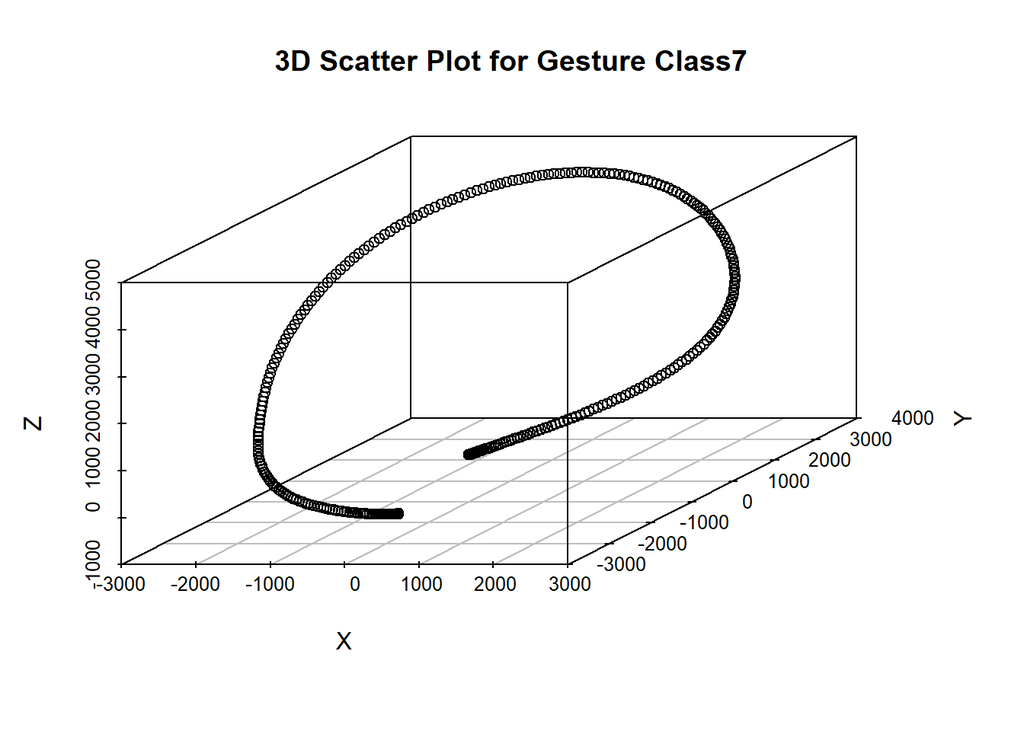

```r
t_class7_x=as.data.frame(t(class7_x[,]))
velocity_class7_x=cumsum(t_class7_x)
loc_class7_x=cumsum(velocity_class7_x)

t_class7_y=as.data.frame(t(class7_y[,]))
velocity_class7_y=cumsum(t_class7_y)
loc_class7_y=cumsum(velocity_class7_y)

t_class7_z=as.data.frame(t(class7_z[,]))
velocity_class7_z=cumsum(t_class7_z)
loc_class7_z=cumsum(velocity_class7_z)

scatterplot3d(x=loc_class7_x[,7], y=loc_class7_y[,7], z=loc_class7_z[,7],main="3D Scatter Plot for Gesture Class7",
              xlab = "X", ylab= "Y", zlab="Z")
```

# 3D PLOT for CLASS 8

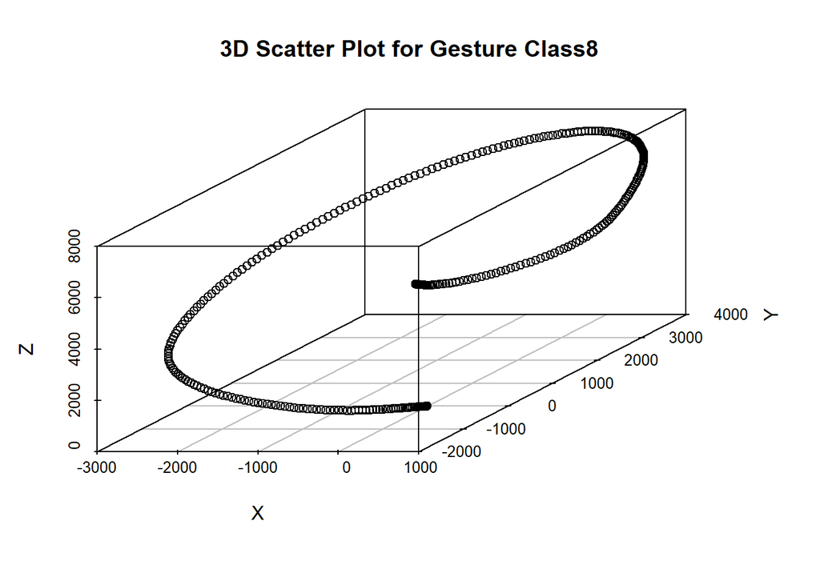

```r
t_class8_x=as.data.frame(t(class8_x[,]))
velocity_class8_x=cumsum(t_class8_x)
loc_class8_x=cumsum(velocity_class8_x)

t_class8_y=as.data.frame(t(class8_y[,]))
velocity_class8_y=cumsum(t_class8_y)
loc_class8_y=cumsum(velocity_class8_y)

t_class8_z=as.data.frame(t(class8_z[,]))
velocity_class8_z=cumsum(t_class8_z)
loc_class8_z=cumsum(velocity_class8_z)

scatterplot3d(x=loc_class8_x[,8], y=loc_class8_y[,8], z=loc_class8_z[,8],main="3D Scatter Plot for Gesture Class8",
              xlab = "X", ylab= "Y", zlab="Z")
```

An instance of each class is plotted on the 3D space as above. Most of them are recognizable except some incorrect sliding moves in the beginnings and ends. Instances of Class 3 and Class 4 are odd.

## 2)

To obtain a simpler representation, I combined X,Y and Z coordinates and calculated euclidean distance from the origin to each point of each instance for all classes.

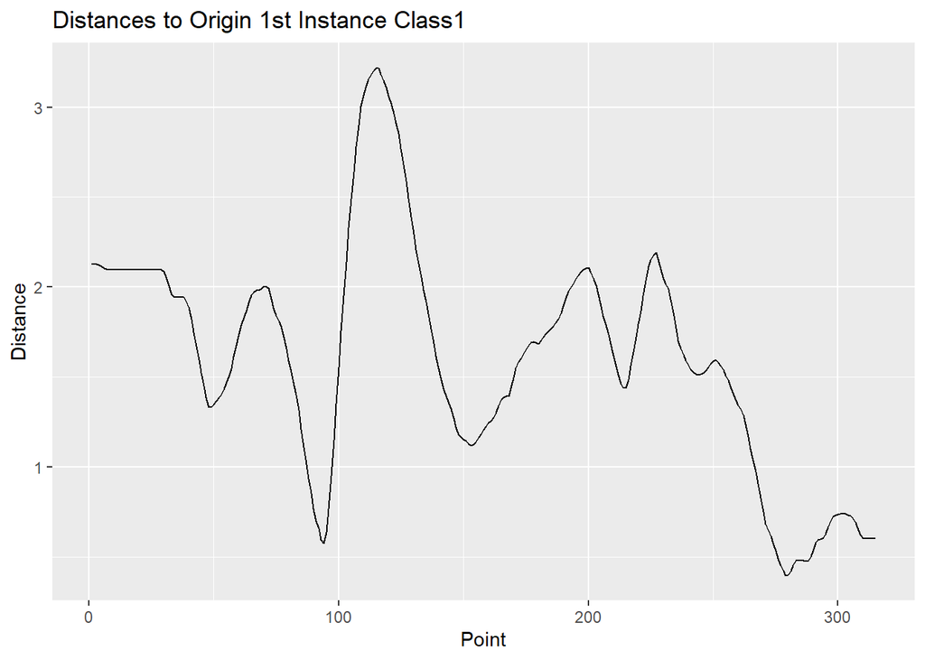

```r
distances_class1 = data.frame()

for( i in 1:nrow(class1_x)){
  for (j in 1:ncol(class1_z)){
    distances_class1[i,j] = sqrt(sum(class1_x[i,j]**2 + class1_y[i,j]**2 + class1_z[i,j]**2))
  }
}


library(ggplot2)

ggplot()+geom_line(aes(x=1:ncol(distances_class1[1,]), y=as.numeric(distances_class1[1,])))+labs(title="Distances to Origin 1st Instance Class1", y="Distance", x="Point")
```

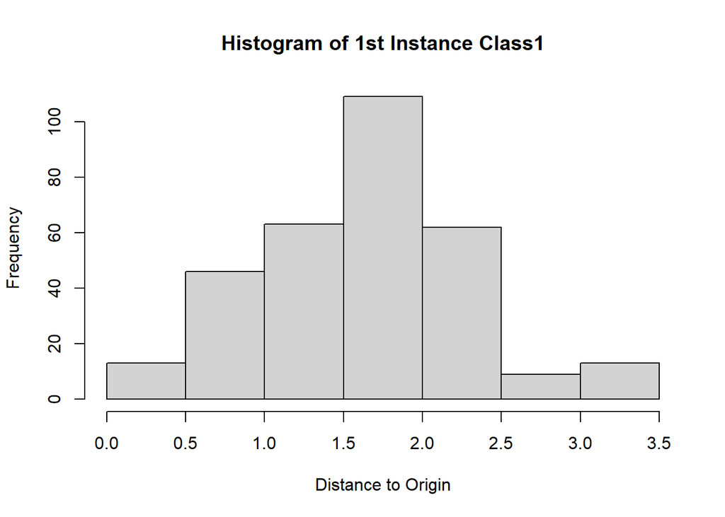

```r
hist(as.numeric(distances_class1[1,]), main="Histogram of 1st Instance Class1", xlab="Distance to Origin")
```

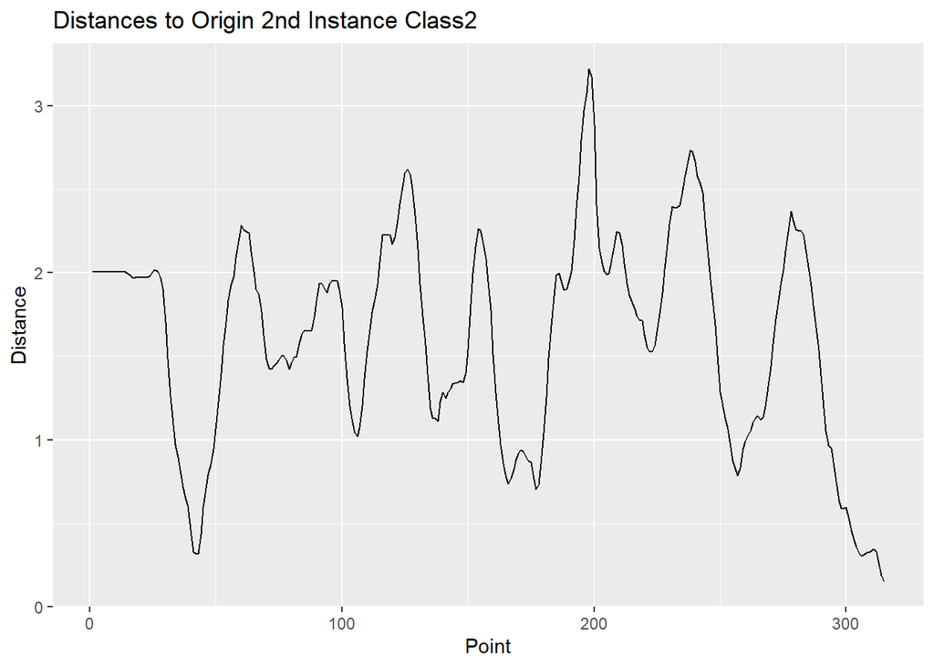

```r
distances_class2 = data.frame()

for( i in 1:nrow(class2_x)){
  for (j in 1:ncol(class2_z)){
    distances_class2[i,j] = sqrt(sum(class2_x[i,j]**2 + class2_y[i,j]**2 + class2_z[i,j]**2))
  }
}

ggplot()+geom_line(aes(x=1:ncol(distances_class2[2,]), y=as.numeric(distances_class2[2,])))+labs(title="Distances to Origin 2nd Instance Class2", y="Distance", x="Point")
```

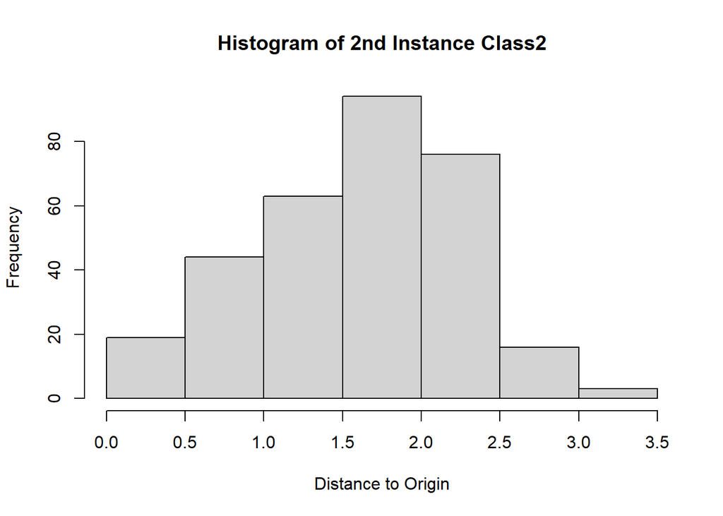

```r
hist(as.numeric(distances_class2[2,]), main="Histogram of 2nd Instance Class2", xlab="Distance to Origin")
```

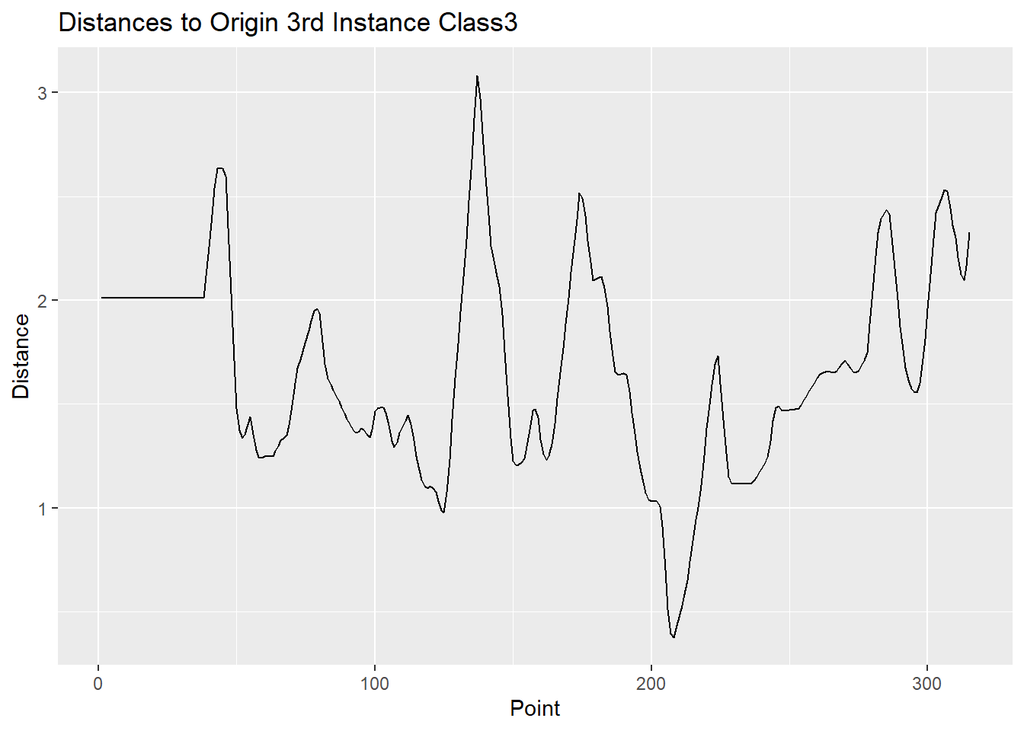

```r
distances_class3 = data.frame()

for( i in 1:nrow(class3_x)){
  for (j in 1:ncol(class3_z)){
    distances_class3[i,j] = sqrt(sum(class3_x[i,j]**2 + class3_y[i,j]**2 + class3_z[i,j]**2))
  }
}


ggplot()+geom_line(aes(x=1:ncol(distances_class3[3,]), y=as.numeric(distances_class3[3,])))+labs(title="Distances to Origin 3rd Instance Class3", y="Distance", x="Point")
```

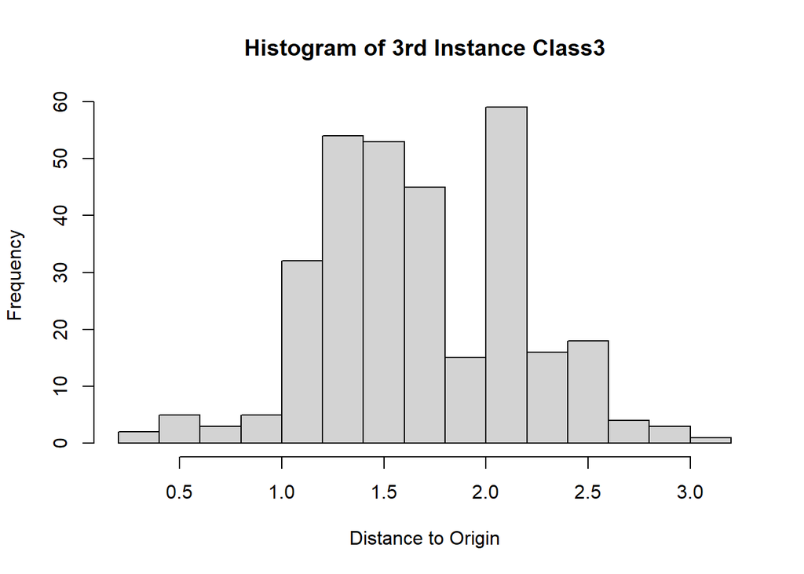

```r
hist(as.numeric(distances_class3[3,]), main="Histogram of 3rd Instance Class3", xlab="Distance to Origin")
```

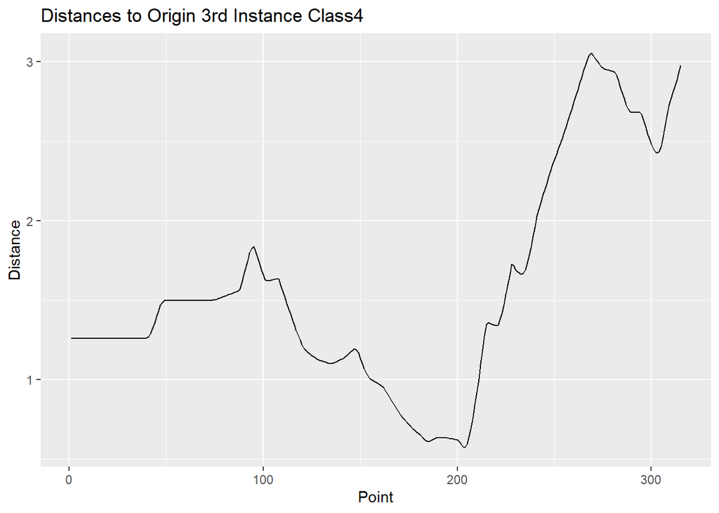

```r
distances_class4 = data.frame()

for( i in 1:nrow(class4_x)){
  for (j in 1:ncol(class4_z)){
    distances_class4[i,j] = sqrt(sum(class4_x[i,j]**2 + class4_y[i,j]**2 + class4_z[i,j]**2))
  }
}


ggplot()+geom_line(aes(x=1:ncol(distances_class4[3,]), y=as.numeric(distances_class4[3,])))+labs(title="Distances to Origin 3rd Instance Class4", y="Distance", x="Point")
```

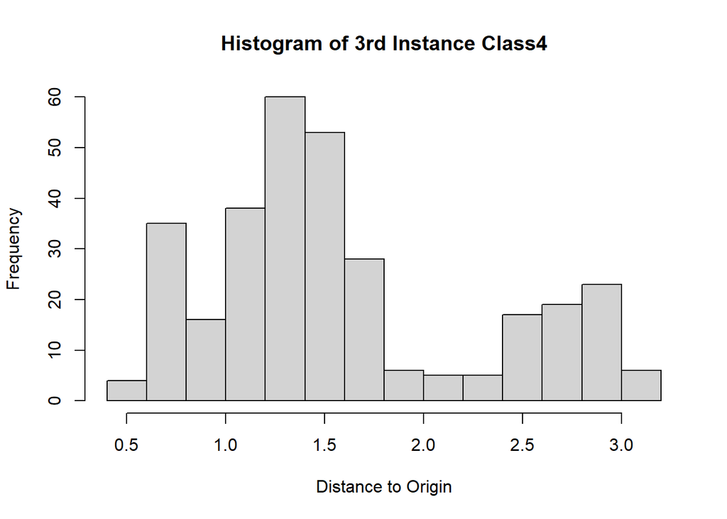

```r
hist(as.numeric(distances_class4[3,]), main="Histogram of 3rd Instance Class4", xlab="Distance to Origin")
```

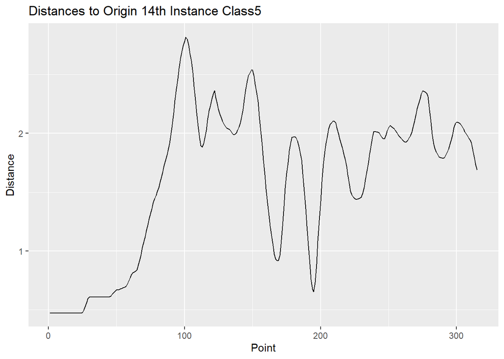

```r
distances_class5 = data.frame()

for( i in 1:nrow(class5_x)){
  for (j in 1:ncol(class5_z)){
    distances_class5[i,j] = sqrt(sum(class5_x[i,j]**2 + class5_y[i,j]**2 + class5_z[i,j]**2))
  }
}


ggplot()+geom_line(aes(x=1:ncol(distances_class5[14,]), y=as.numeric(distances_class5[14,])))+labs(title="Distances to Origin 14th Instance Class5", y="Distance", x="Point")
```

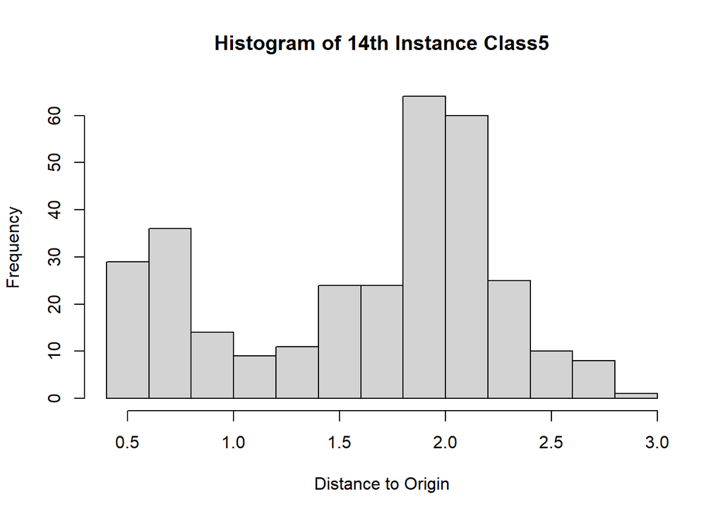

```r
hist(as.numeric(distances_class5[14,]), main="Histogram of 14th Instance Class5", xlab="Distance to Origin")
```

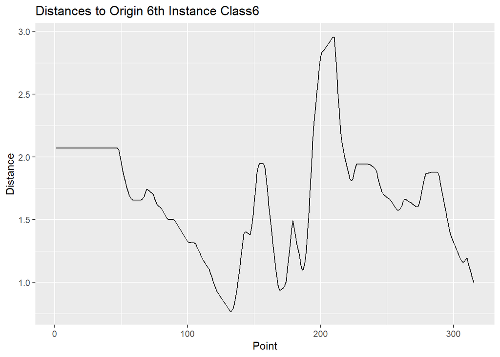

```r
distances_class6 = data.frame()

for( i in 1:nrow(class6_x)){
  for (j in 1:ncol(class6_z)){
    distances_class6[i,j] = sqrt(sum(class6_x[i,j]**2 + class6_y[i,j]**2 + class6_z[i,j]**2))
  }
}


ggplot()+geom_line(aes(x=1:ncol(distances_class6[6,]), y=as.numeric(distances_class6[6,])))+labs(title="Distances to Origin 6th Instance Class6", y="Distance", x="Point")
```

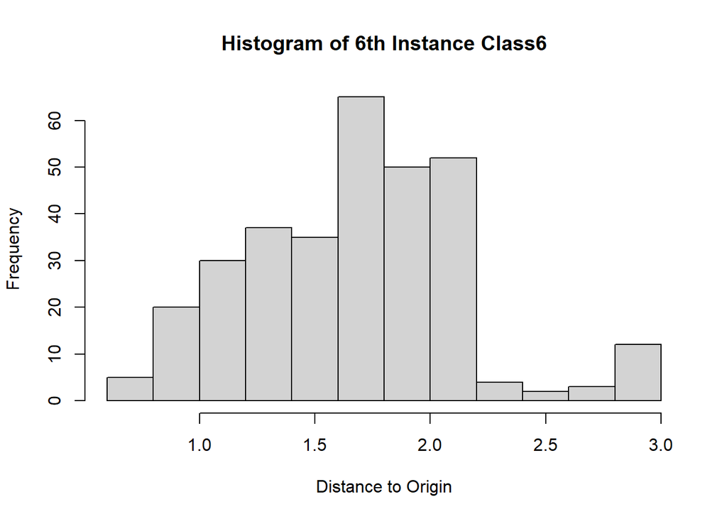

```r
hist(as.numeric(distances_class6[6,]), main="Histogram of 6th Instance Class6", xlab="Distance to Origin")
```

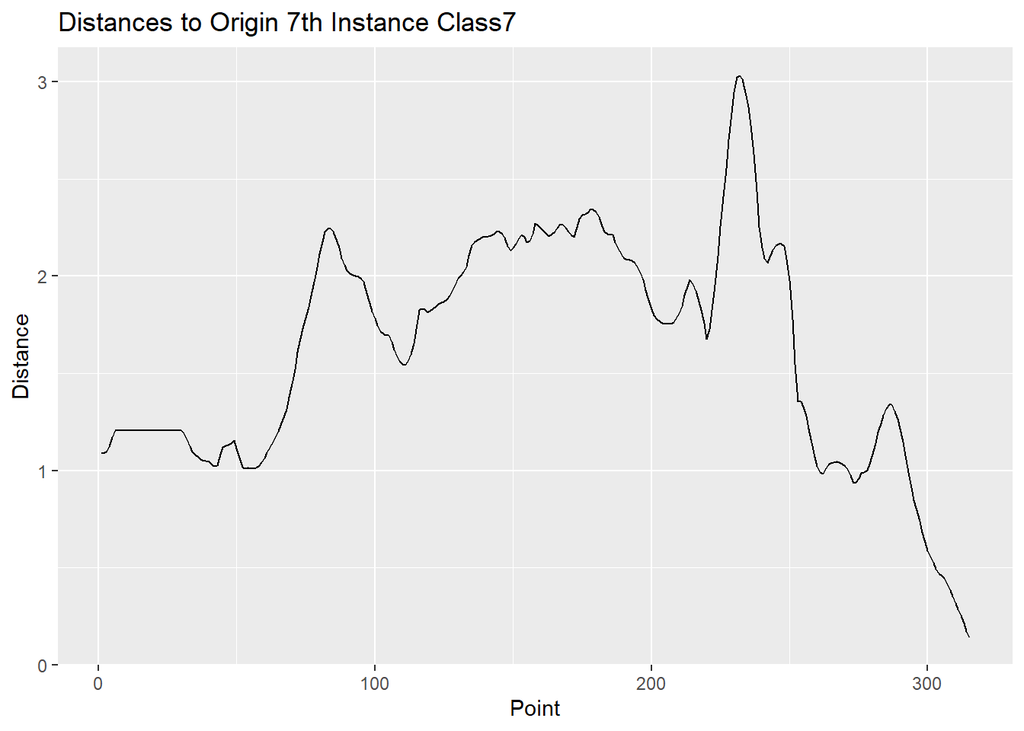

```r
distances_class7 = data.frame()

for( i in 1:nrow(class7_x)){
  for (j in 1:ncol(class7_z)){
    distances_class7[i,j] = sqrt(sum(class7_x[i,j]**2 + class7_y[i,j]**2 + class7_z[i,j]**2))
  }
}


ggplot()+geom_line(aes(x=1:ncol(distances_class7[7,]), y=as.numeric(distances_class7[7,])))+labs(title="Distances to Origin 7th Instance Class7", y="Distance", x="Point")
```

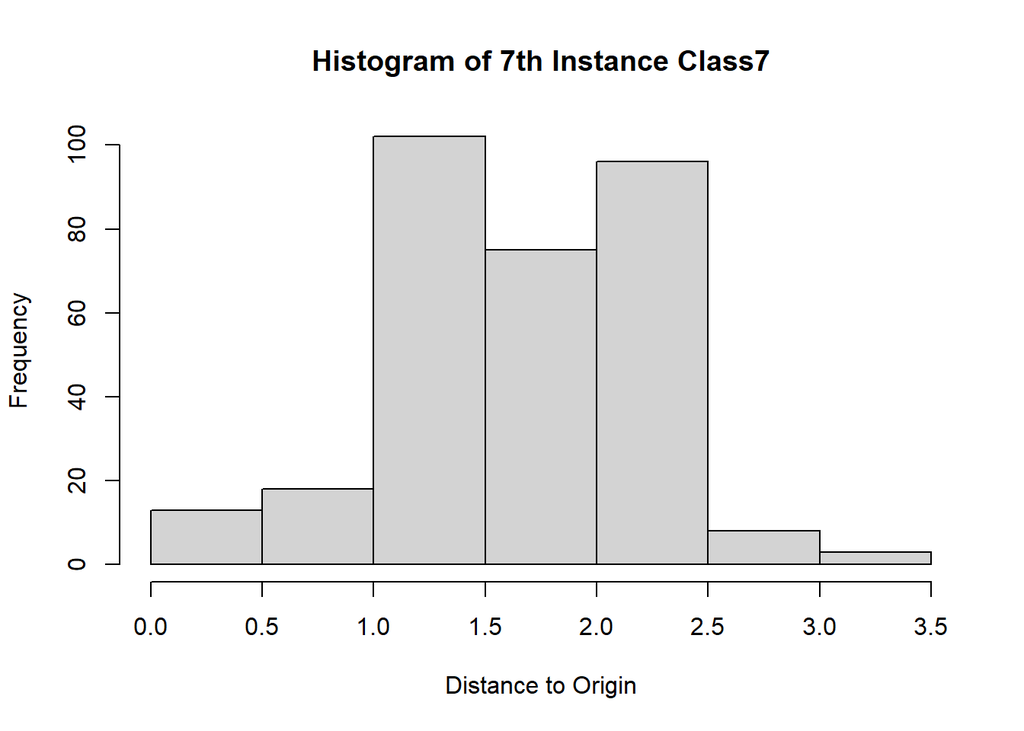

```r
hist(as.numeric(distances_class7[7,]), main="Histogram of 7th Instance Class7", xlab="Distance to Origin")
```

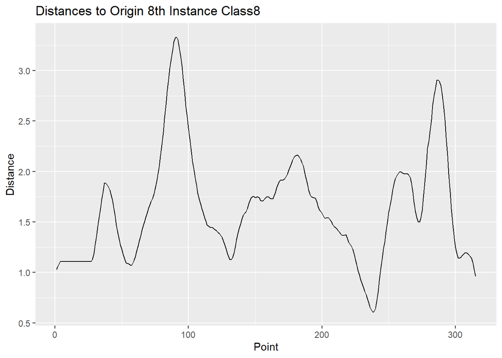

```r
distances_class8 = data.frame()

for( i in 1:nrow(class8_x)){
  for (j in 1:ncol(class8_z)){
    distances_class8[i,j] = sqrt(sum(class8_x[i,j]**2 + class8_y[i,j]**2 + class8_z[i,j]**2))
  }
}


ggplot()+geom_line(aes(x=1:ncol(distances_class8[8,]), y=as.numeric(distances_class8[8,])))+labs(title="Distances to Origin 8th Instance Class8", y="Distance", x="Point")
```

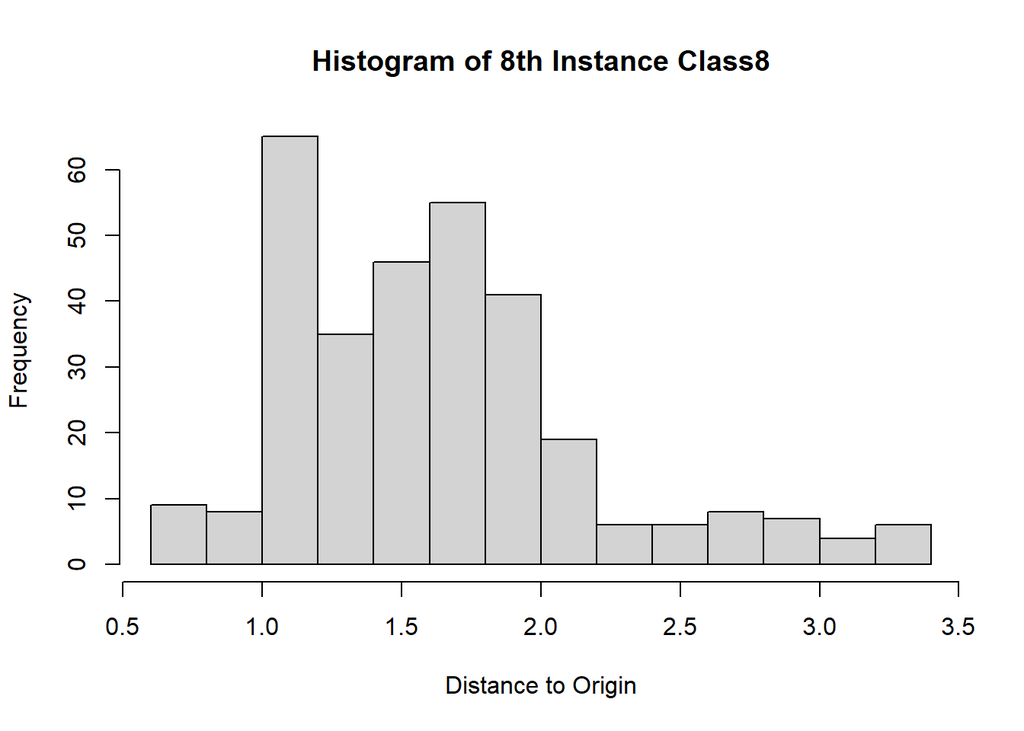

```r
hist(as.numeric(distances_class8[8,]), main="Histogram of 8th Instance Class8", xlab="Distance to Origin")
```

I used SAX representation as a piecewise model to represent distance information.

```r
library(TSrepr)
library(data.table)

sax_segment_length=5
sax_alphabet_size=10
alphabet=list("a","b","c","d","e","f","g","h","i","j")


print('Class 1 Instance 1 SAX Representation')
```

```
## [1] "Class 1 Instance 1 SAX Representation"
```

```r
sax_rep_class1=repr_sax(distances_class1[1,], q = sax_segment_length, a = sax_alphabet_size)
sax_rep_class1
```

```
##  [1] "j" "j" "j" "j" "j" "j" "j" "j" "j" "j" "j" "j" "j" "j" "j" "j" "j" "i" "h"
## [20] "i" "j" "j" "j" "j" "j" "j" "j" "j" "j" "i" "i" "i" "j" "j" "j" "j" "j" "j"
## [39] "j" "j" "j" "j" "j" "j" "j" "j" "j" "j" "j" "j" "j" "j" "i" "i" "h" "g" "g"
## [58] "g" "h" "h" "h" "h" "h"
```

```r
dummy_class1=c(1:(length(sax_rep_class1)-1))*sax_segment_length
dummy_class1=c(dummy_class1,length(distances_class1[1,]))
dt_sax_1=data.table(time=dummy_class1,sax_rep_char=sax_rep_class1)


dt_sax_1
```

```
##     time sax_rep_char
##  1:    5            j
##  2:   10            j
##  3:   15            j
##  4:   20            j
##  5:   25            j
##  6:   30            j
##  7:   35            j
##  8:   40            j
##  9:   45            j
## 10:   50            j
## 11:   55            j
## 12:   60            j
## 13:   65            j
## 14:   70            j
```

[output cut: 50 more lines]

```r
alpha_1 = data.frame(alphabet)
k=1
for (i in alphabet){
  print(c(i,'count for class 1 instance 1', print(sum(dt_sax_1==i))))
  alpha_1[2,k] = sum(dt_sax_1==i)
  k=k+1
}
```

```
## [1] 0
## [1] "a"                            "count for class 1 instance 1"
## [3] "0"
## [1] 0
## [1] "b"                            "count for class 1 instance 1"
## [3] "0"
## [1] 0
## [1] "c"                            "count for class 1 instance 1"
## [3] "0"
## [1] 0
## [1] "d"                            "count for class 1 instance 1"
## [3] "0"
## [1] 0
## [1] "e"                            "count for class 1 instance 1"
## [3] "0"
## [1] 0
## [1] "f"                            "count for class 1 instance 1"
## [3] "0"
## [1] 3
## [1] "g"                            "count for class 1 instance 1"
## [3] "3"
## [1] 7
## [1] "h"                            "count for class 1 instance 1"
## [3] "7"
## [1] 7
## [1] "i"                            "count for class 1 instance 1"
## [3] "7"
## [1] 46
## [1] "j"                            "count for class 1 instance 1"
## [3] "46"
```

```r
alpha_1
```

```
##   X.a. X.b. X.c. X.d. X.e. X.f. X.g. X.h. X.i. X.j.
## 1    a    b    c    d    e    f    g    h    i    j
## 2    0    0    0    0    0    0    3    7    7   46
```

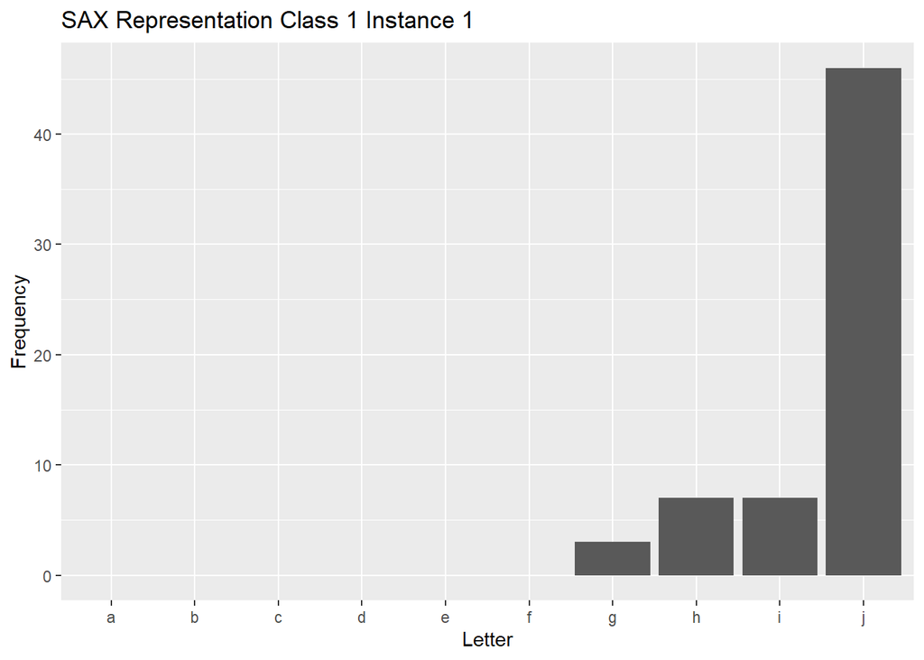

```r
ggplot()+geom_col(aes(x=(as.character(alpha_1[1,])),y=as.numeric(alpha_1[2,])))+labs(title="SAX Representation Class 1 Instance 1",
                                                                                     x="Letter", y="Frequency")
```

```r
print('Class 2 Instance 2 SAX Representation')
```

```
## [1] "Class 2 Instance 2 SAX Representation"
```

```r
sax_rep_class2=repr_sax(distances_class2[2,], q = sax_segment_length, a = sax_alphabet_size)
sax_rep_class2
```

```
##  [1] "j" "j" "j" "j" "j" "j" "i" "h" "g" "i" "j" "j" "j" "j" "j" "j" "j" "j" "j"
## [20] "j" "i" "i" "j" "j" "j" "j" "j" "i" "j" "j" "j" "j" "i" "h" "i" "h" "j" "j"
## [39] "j" "j" "j" "j" "j" "j" "j" "j" "j" "j" "j" "j" "i" "i" "i" "i" "j" "j" "j"
## [58] "j" "i" "h" "g" "g" "f"
```

```r
dummy_class2=c(1:(length(sax_rep_class2)-1))*sax_segment_length
dummy_class2=c(dummy_class2,length(distances_class2[2,]))
dt_sax_2=data.table(time=dummy_class2,sax_rep_char=sax_rep_class2)

dt_sax_2
```

```
##     time sax_rep_char
##  1:    5            j
##  2:   10            j
##  3:   15            j
##  4:   20            j
##  5:   25            j
##  6:   30            j
##  7:   35            i
##  8:   40            h
##  9:   45            g
## 10:   50            i
## 11:   55            j
## 12:   60            j
## 13:   65            j
## 14:   70            j
```

[output cut: 50 more lines]

```r
alpha_2 = data.frame(alphabet)
k=1
for (i in alphabet){
  print(c(i,'count for class 2 instance 2', print(sum(dt_sax_2==i))))
  alpha_2[2,k] = sum(dt_sax_2==i)
  k=k+1
}
```

```
## [1] 0
## [1] "a"                            "count for class 2 instance 2"
## [3] "0"
## [1] 0
## [1] "b"                            "count for class 2 instance 2"
## [3] "0"
## [1] 0
## [1] "c"                            "count for class 2 instance 2"
## [3] "0"
## [1] 0
## [1] "d"                            "count for class 2 instance 2"
## [3] "0"
## [1] 0
## [1] "e"                            "count for class 2 instance 2"
## [3] "0"
## [1] 1
## [1] "f"                            "count for class 2 instance 2"
## [3] "1"
## [1] 3
## [1] "g"                            "count for class 2 instance 2"
## [3] "3"
## [1] 4
## [1] "h"                            "count for class 2 instance 2"
## [3] "4"
## [1] 12
## [1] "i"                            "count for class 2 instance 2"
## [3] "12"
## [1] 43
## [1] "j"                            "count for class 2 instance 2"
## [3] "43"
```

```r
alpha_2
```

```
##   X.a. X.b. X.c. X.d. X.e. X.f. X.g. X.h. X.i. X.j.
## 1    a    b    c    d    e    f    g    h    i    j
## 2    0    0    0    0    0    1    3    4   12   43
```

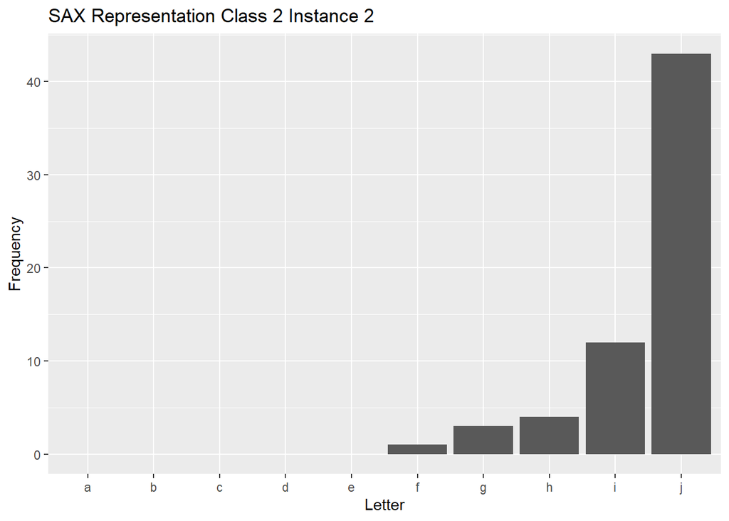

```r
ggplot()+geom_col(aes(x=(as.character(alpha_2[1,])),y=as.numeric(alpha_2[2,])))+labs(title="SAX Representation Class 2 Instance 2",
                                                                                     x="Letter", y="Frequency")
```

```r
print('Class 3 Instance 3 SAX Representation')
```

```
## [1] "Class 3 Instance 3 SAX Representation"
```

```r
sax_rep_class3=repr_sax(distances_class3[3,], q = sax_segment_length, a = sax_alphabet_size)
sax_rep_class3
```

```
##  [1] "j" "j" "j" "j" "j" "j" "j" "j" "j" "j" "j" "i" "i" "j" "j" "j" "j" "j" "j"
## [20] "j" "j" "j" "j" "i" "i" "j" "j" "j" "j" "j" "i" "j" "j" "j" "j" "j" "j" "j"
## [39] "j" "i" "i" "g" "h" "i" "j" "i" "i" "i" "j" "j" "j" "j" "j" "j" "j" "j" "j"
## [58] "j" "j" "j" "j" "j" "j"
```

```r
dummy_class3=c(1:(length(sax_rep_class3)-1))*sax_segment_length
dummy_class3=c(dummy_class3,length(distances_class3[3,]))
dt_sax_3=data.table(time=dummy_class3,sax_rep_char=sax_rep_class3)


dt_sax_3
```

```
##     time sax_rep_char
##  1:    5            j
##  2:   10            j
##  3:   15            j
##  4:   20            j
##  5:   25            j
##  6:   30            j
##  7:   35            j
##  8:   40            j
##  9:   45            j
## 10:   50            j
## 11:   55            j
## 12:   60            i
## 13:   65            i
## 14:   70            j
```

[output cut: 50 more lines]